# Inaccesibilidad sanitaria y efectos en la salud

Lorena González Martínez, Alba Miguel Pastor, Noelia Pérez Gómez

27/10/2021

## **Introducción**

La accesibilidad a la asistencia sanitaria es fundamental para garantizar la equidad del sistema sanitario. Los pacientes deben de recibir una atención oportuna, rápida y adecuada a sus condiciones de salud.

La **inaccesibilidad** se define como aquello que no está accesible, es decir, sin acceso o trato.

A través de este trabajo analizaremos algunos de los aspectos que actualmente desencadenan situaciones de inaccesibilidad en las distintas comunidades autónomas de España. Entre otros, la inaccesibilidad por dificultades económicas o de transporte.

El informe consta de diferentes partes. En primer lugar, presentaremos los objetivos. Después desarrollaremos la metodología que vamos a utilizar para abordar cada uno de ellos, y por último, incidiremos en la importación y el análisis de los datos,así como las correspondientes conclusiones.

Vamos a abordar este tema, ya que nos parece que es uno de los problemas que concierne a la sociedad en la actualidad y que se ha intensificado por la pandemia. Por ejemplo, debido a la despoblación rural una parte de la población ha perdido la libertad de acudir al médico directamente en caso de necesidad por la reducción de horarios de visita y de personal sanitario, afectando principalmente a los más vulnerables.

Adjuntamos el link del [repositorio](https://github.com/albamiguel/Inaccesibilidad-sanitaria-y-efectos-en-salud)

## **Objetivos**

*OBJETIVO GENERAL*:

Comprobar la relación entre la inaccesibilidad a la sanidad y los efectos que puede provocar en la salud humana.

*OBEJTIVOS ESPECÍFICOS*:

-Inaccesibilidad por motivos económicos y comunidad autónoma

-Relación entre los casos de muerte y la inaccesibilidad (por comunidad autónoma)

-Inaccesibilidad y dificultades de transporte (por comunidad autónoma y por sexos)

## **Metodología**

### **PROCEDENCIA DE LOS DATOS**:

Hemos extraído los datos del **Instituto Nacional de Estadística (INE)**. El INE es un organismo autónomo de carácter administrativo, con personalidad jurídica y patrimonio propio, adscrito al Ministerio de Asuntos Económicos y Transformación Digital a través de la Secretaría de Estado de Economía y Apoyo a la Empresa.Ver [aqui](https://www.ine.es/index.htm)

Está encargado de producir información estadística de la más alta calidad acerca de numerosos ámbitos como la economía, la sociedad y el medio ambiente, entre otros, para favorecer así la correcta toma de decisiones.

En este sitio web hemos encontrado una gran cantidad de información estadística de libre acceso (OA), en diversidad de formatos.

**Datos**:

- [Inaccesibilidad por motivos económicos](https://www.ine.es/jaxi/Tabla.htm?path=/t15/p420/a2019/p02/l0/&file=05016.px&L=0)
- [Defunciones por comunidad autónoma](https://www.ine.es/jaxi/Datos.htm?tpx=21856)
- [Demora excesiva o inaccesibilidad a la asistencia médica](https://www.ine.es/jaxi/Tabla.htm?path=/t15/p419/a2017/p02/l0/&file=05004.px&L=0)
- [Inaccesibilidad por dificultades con el transporte](https://www.ine.es/jaxi/Tabla.htm?path=/t15/p420/a2019/p02/l0/&file=05010.px&L=0)

### **DESCRIPCIÓN DEL SET DE DATOS**:

Por un lado, los sets de datos que hemos empleado son de tipo *.csv*.

El formato *.csv* (“*Comma Separated Values*”) son archivos de texto en los cuales los caracteres están separados por comas, dando lugar a una especie de tabla en forma de filas y columnas. Las columnas quedan definidas por cada punto y coma (;), mientras que cada fila se define mediante una línea adicional en el texto.

Los archivos *.csv* sirven para manejar una gran cantidad de datos en formato tabla, sin que ello conlleve sobrecoste computacional alguno, por eso mismo hemos considerado que es el más eficiente para llevar a cabo la importación de datos.

Pero, antes de nada tenemos que importar el paquete readr, que se trata de una herramienta que permite trabajar con los ficheros de datos.

Por otro lado, el otro tipo de set de datos que hemos utilizado es formato Excel.Es una hoja de cálculo desarrollada por Microsoft, que permite administrar los datos de una manera muy simple.

Para trabajar con datos de Excel en R debemos usar un paquete desarrollado para tal fin (readxl).

### **RESOLUCIÓN TEMPORAL**:

Últimos 12 meses del año 2020.

### **RESOLUCIÓN ESPACIAL**:

Por comunidades autónomas de España. Está integrada por 17 Autonomías (Andalucía, Aragón, Asturias, Baleares, Canarias, Cantabria, Castilla la Mancha, Castilla y León, Cataluña, Comunidad Valenciana, Extremadura, Galicia, La Rioja, Madrid, Murcia, Navarra y País Vasco), cada una con su capital, más dos ciudades autónomas, Ceuta y Melilla, reconocidas así por sus propios estatutos.Las Comunidades Autónomas son, por tanto, divisiones territoriales con capacidad de administración y legislación y con competencia para ejecutar leyes.

### **POBLACIÓN**:

Personas de 15 o más años, tanto hombres como mujeres, expecto en el data set de defunciones por comunidad autónoma, que entran todos los rangos de edad.

### **HERRAMIENTAS UTILIZADAS** $\rightarrow$ **DATOS**:

### **Inaccesibilidad por motivos económicos (por comunidad autónoma)**:

- Importamos el set de datos del INE sobre la inaccesibilidad sanitaria por motivos ecónomicos agrupados por comunidad autónoma.

```r
   library(readr)
   Inaccesibilidad_por_motivos_economicos <-
   read_csv2("DATOS/Inaccesibilidad por motivos economicos.csv")
```

```
## i Using "','" as decimal and "'.'" as grouping mark. Use `read_delim()` for more control.
```

### Análisis de los datos

- Obtenemos el número de columnas que tiene:

```r
str(Inaccesibilidad_por_motivos_economicos)
```

```
## spec_tbl_df [1,200 x 5] (S3: spec_tbl_df/tbl_df/tbl/data.frame)
##  $ Sexo                    : chr [1:1200] "Ambos sexos" "Ambos sexos" "Ambos sexos" "Ambos sexos" ...
##  $ Comunidad autónoma      : chr [1:1200] "Total Nacional" "Total Nacional" "Total Nacional" "Total Nacional" ...
##  $ Tipos atención sanitaria: chr [1:1200] "Atención médica" "Atención médica" "Atención médica" "Atención médica" ...
##  $ Sí o no                 : chr [1:1200] "TOTAL" "Sí" "No" "No necesitó asistencia" ...
##  $ Total                   : num [1:1200] 39974.1 739.2 37909.7 1313.7 11.5 ...
##  - attr(*, "spec")=
##   .. cols(
##   ..   Sexo = col_character(),
##   ..   `Comunidad autónoma` = col_character(),
##   ..   `Tipos atención sanitaria` = col_character(),
##   ..   `Sí o no` = col_character(),
##   ..   Total = col_number()
##   .. )
##  - attr(*, "problems")=<externalptr>
```

- Especificamos de que tipo son:

```r
spec(Inaccesibilidad_por_motivos_economicos)
```

- Obtenemos resumen de los resultados:

```r
summary(Inaccesibilidad_por_motivos_economicos)
```

```
##      Sexo           Comunidad autónoma Tipos atención sanitaria
##  Length:1200        Length:1200        Length:1200
##  Class :character   Class :character   Class :character
##  Mode  :character   Mode  :character   Mode  :character
##
##
##
##    Sí o no              Total
##  Length:1200        Min.   :    0.00
##  Class :character   1st Qu.:    1.90
##  Mode  :character   Median :   67.35
##                     Mean   : 1065.98
##                     3rd Qu.:  650.28
##                     Max.   :39974.10
```

-**Nuestro set de datos esta compuesto por 5 columnas:**

- **Sexo**: compuesto por 1200 elementos, clase caracter. Pueden ser hombres, mujeres o ambos sexos.
- **Comunidad autonónoma**: compuesto por 1200 elementos, clase caracter. Dividido por el total nacional y las diferentes comunidades autonomas (Andalucia, Aragón, Asturias, Islas Baleares, Canarias, Cantabria, Castilla y León, Castilla la Mancha, Cataluña,Comunitat Valenciana, Extremadura, Galicia, Madrid, Región de Murcia, Comunidad Foral de Navarra, País Vasco, La Rioja, Cueuta, Melilla).
- **Tipos atención sanitaria**: compuesto por 1200 elementos, de clase caracter.Encontramos distintos tipos de atención sanitaria, que puede ser atencion medica,dental, medicamento recetado,atencion salud mental,
- **Si o No**: compuesto por 1200 elementos, clase caracter. Muestra cuantas personas participaron en la encuesta, el total esta divididos en las personas que SI sufrieron inaccsesibilidad, quienes NO, las personas que no necesitaron asistencia y por último las que no constan.
- **Total**: compuesto por 1200 elementos clase numerica. Es el recuento total de cada variable distinta.

```r
library(tidyverse)
```

- Seleccionamos sólo aquellas variables que nos interesan: Sí o no / Total/ Comunidad autónoma / Tipos de atención sanitaria / Sexo

```r
Inaccesibilidad_m_economicos <-
  Inaccesibilidad_por_motivos_economicos %>%
  select(`Comunidad autónoma`, `Sí o no`, Total,`Sexo`,`Tipos atención sanitaria`)

Inaccesibilidad_m_economicos
```

```
## # A tibble: 1,200 x 5
##    `Comunidad autónoma` `Sí o no`                Total Sexo        `Tipos atención~
##    <chr>                <chr>                    <dbl> <chr>       <chr>
##  1 Total Nacional       TOTAL                  39974.  Ambos sexos Atención médica
##  2 Total Nacional       Sí                       739.  Ambos sexos Atención médica
##  3 Total Nacional       No                     37910.  Ambos sexos Atención médica
##  4 Total Nacional       No necesitó asistencia  1314.  Ambos sexos Atención médica
##  5 Total Nacional       No consta                 11.5 Ambos sexos Atención médica
##  6 Total Nacional       TOTAL                  39974.  Ambos sexos Atención dental
##  7 Total Nacional       Sí                      3697.  Ambos sexos Atención dental
##  8 Total Nacional       No                     32543   Ambos sexos Atención dental
##  9 Total Nacional       No necesitó asistencia  3710.  Ambos sexos Atención dental
## 10 Total Nacional       No consta                 24.8 Ambos sexos Atención dental
## # ... with 1,190 more rows
```

```r
Datos_filtrados_economicos<-
Inaccesibilidad_m_economicos %>%
  filter(`Comunidad autónoma`!="Total Nacional" & `Sí o no` != "TOTAL" & `Sí o no` != "No" & `Sí o no` != "No necesitó asistencia" & `Sí o no` != "No consta",`Sexo` != "Hombres"&`Sexo` !="Mujeres"& `Tipos atención sanitaria`!="Medicamento recetado")%>%
group_by(`Comunidad autónoma`,`Sexo`,`Tipos atención sanitaria`,`Total`)

str(Datos_filtrados_economicos)
```

[output not shown]

[output cut: 16 more lines]

```
##   .. ..$ : int 57
##   .. ..$ : int 41
##   .. ..$ : int 40
##   .. ..$ : int 42
##   .. ..$ : int 44
##   .. ..$ : int 43
##   .. ..$ : int 45
##   .. ..$ : int 47
##   .. ..$ : int 46
##   .. ..$ : int 48
##   .. ..$ : int 50
##   .. ..$ : int 49
##   .. ..$ : int 51
##   .. ..@ ptype: int(0)
##   ..- attr(*, ".drop")= logi TRUE
```

### Gráfico:

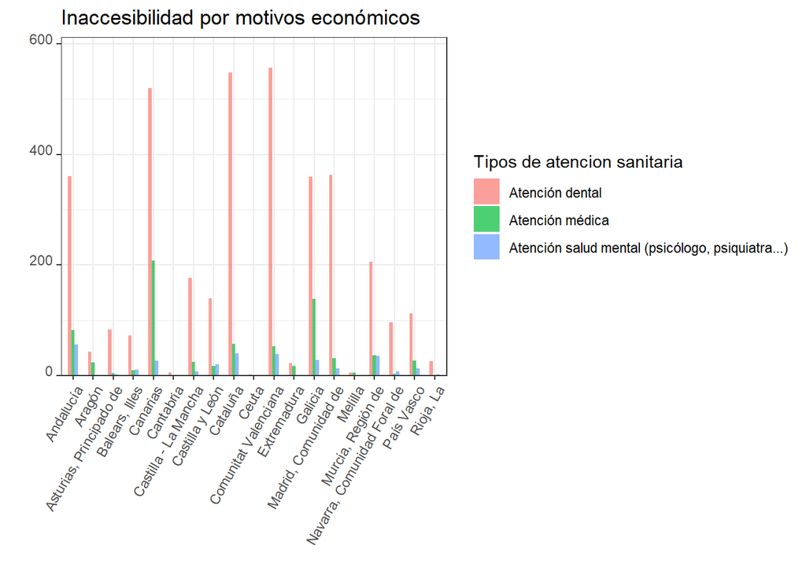

```r
Resultado1 <-
Datos_filtrados_economicos %>%
 drop_na() %>%
 ggplot(data =.,
       mapping = aes(x =`Comunidad autónoma`, y = Total, fill=factor(`Tipos atención sanitaria`))) +
 geom_bar(stat='identity',position='dodge',width = 0.5, alpha= 0.7)+
 theme_bw()+
 theme(axis.text.x = element_text(angle = 60, vjust = 1, hjust=1))+
 theme(axis.text.y = element_text(angle = 0, vjust = 0, hjust=1))+
 labs(title= "Inaccesibilidad por motivos económicos", x= " ", y= "  ",fill="Tipos de atencion sanitaria")+
 scale_y_continuous(expand = expansion(mult = c(0, .1)))

Resultado1
```

### Conclusiones

En el gráfico anterior se muestran las personas que han sufrido inaccesibilidad a la asistencia sanitaria por motivos económicos.

Hemos realizado la comparación por Comunidades Autónomas por orden alfabético y en el eje y, el total de los datos. Hemos gráficado segun los tres tipos de asistencia sanitaria: La atención dental (rosa), la atención médica (verde) y la salud mental (azul), por lo que para cada una de las comunidades autonomas vamos a obtener tres barras.

### **Relación entre los casos de muerte y la inaccesibilidad (por comunidad autónoma)**:

```r
library(tidyverse)
```

- Importamos el set de datos del INE de defunciones por comunidad autónoma de residencia.

```r
library(readxl)
Muerte_inaccesibilidad <- read_excel("DATOS/Muerte_inaccesibilidad.xlsx")
```

### Análisis de los datos

- Seleccionamos sólo aquellas variables que nos interesan: Total / Comunidad autónoma de residencia

```r
Muerte_inaccesibilidad1 <-
Muerte_inaccesibilidad %>%
  select(`Comunidad autónoma de residencia del fallecido`, Total_muertes = Total) %>%
  filter(`Comunidad autónoma de residencia del fallecido` != "Total") %>%
  filter(`Comunidad autónoma de residencia del fallecido` != "Extranjero")
```

- Vista general:

```r
summary(Muerte_inaccesibilidad1)
```

```
##  Comunidad autónoma de residencia del fallecido Total_muertes
##  Length:19                                      Min.   :  601
##  Class :character                               1st Qu.: 7612
##  Mode  :character                               Median :16416
##                                                 Mean   :25874
##                                                 3rd Qu.:34500
##                                                 Max.   :79685
```

```r
str(Muerte_inaccesibilidad1)
```

```
## tibble [19 x 2] (S3: tbl_df/tbl/data.frame)
##  $ Comunidad autónoma de residencia del fallecido: chr [1:19] "Andalucía" "Aragón" "Asturias, Principado de" "Balears, Illes" ...
##  $ Total_muertes                                 : num [1:19] 78160 16680 14550 8562 16416 ...
```

- Importamos el set de datos del INE de inaccesibilidad por comunidad autónoma.

```r
library(readxl)
inaccesibilidad_comunidades <- read_excel("DATOS/inaccesibilidad_comunidades.xlsx")
```

- Vista general:

```r
summary(inaccesibilidad_comunidades)
```

```
##      Sexo           Comunidad autónoma   Sí o no              Total
##  Length:240         Length:240         Length:240         Min.   :  0.00
##  Class :character   Class :character   Class :character   1st Qu.: 15.76
##  Mode  :character   Mode  :character   Mode  :character   Median : 40.22
##                                                           Mean   : 50.00
##                                                           3rd Qu.: 93.87
##                                                           Max.   :100.00
```

```r
str(inaccesibilidad_comunidades)
```

```
## tibble [240 x 4] (S3: tbl_df/tbl/data.frame)
##  $ Sexo              : chr [1:240] "AMBOS SEXOS" "AMBOS SEXOS" "AMBOS SEXOS" "AMBOS SEXOS" ...
##  $ Comunidad autónoma: chr [1:240] "Total Nacional" "Total Nacional" "Total Nacional" "Total Nacional" ...
##  $ Sí o no           : chr [1:240] "Total" "Sí" "No" "No necesitó asistencia" ...
##  $ Total             : num [1:240] 100 15.4 66.9 17.6 100 ...
```

- Seleccionamos sólo aquellas variables que nos interesan: Sí o no / Total

```r
inaccesibilidad_comunidades %>%
  select(`Comunidad autónoma`, `Sí o no`, Total)
```

```
## # A tibble: 240 x 3
##    `Comunidad autónoma` `Sí o no`              Total
##    <chr>                <chr>                  <dbl>
##  1 Total Nacional       Total                  100
##  2 Total Nacional       Sí                      15.4
##  3 Total Nacional       No                      66.9
##  4 Total Nacional       No necesitó asistencia  17.6
##  5 Andalucía            Total                  100
##  6 Andalucía            Sí                      14.1
##  7 Andalucía            No                      60.8
##  8 Andalucía            No necesitó asistencia  25.0
##  9 Aragón               Total                  100
## 10 Aragón               Sí                      19.9
## # ... with 230 more rows
```

- Realizamos un full join entre ambos sets de datos, utilizando como elemento de unión la comunidad autónoma, y lo guardamos en un objeto llamado "Correlacion_muerte_inaccesibilidad

```r
Correlacion_muerte_inaccesibilidad <-
Muerte_inaccesibilidad1 %>%
  select(`Comunidad autónoma de residencia del fallecido`, Total_muertes) %>%
  full_join(x = .,
            y = inaccesibilidad_comunidades %>%
              select(`Comunidad autónoma`, `Sí o no`, Total),
            by = c("Comunidad autónoma de residencia del fallecido" = "Comunidad autónoma"))
```

- Comprobamos las variables del nuevo set de datos creado a partir de los anteriores, y el número de repeticiones que aparece en cada una de ellas:

```r
Correlacion_muerte_inaccesibilidad
```

```
## # A tibble: 240 x 4
##    `Comunidad autónoma de residencia del ~ Total_muertes `Sí o no`         Total
##    <chr>                                           <dbl> <chr>             <dbl>
##  1 Andalucía                                       78160 Total             100
##  2 Andalucía                                       78160 Sí                 14.1
##  3 Andalucía                                       78160 No                 60.8
##  4 Andalucía                                       78160 No necesitó asis~  25.0
##  5 Andalucía                                       78160 Total             100
##  6 Andalucía                                       78160 Sí                 13.3
##  7 Andalucía                                       78160 No                 58.6
##  8 Andalucía                                       78160 No necesitó asis~  28.1
##  9 Andalucía                                       78160 Total             100
## 10 Andalucía                                       78160 Sí                 14.9
## # ... with 230 more rows
```

```r
table(Correlacion_muerte_inaccesibilidad$`Sí o no`)
```

```
##
##                     No No necesitó asistencia                     Sí
##                     60                     60                     60
##                  Total
##                     60
```

- Como en nuestro set de datos, no se especifica cuál es la diferencia entre “No” y “No necesitó asistencia”, hemos dado por hecho que “No necesitó asistencia” implica que no hubo inaccesibilidad sanitaria, y por tanto, hemos sumado los datos de ambas variables en una única (“No”):

```r
Resultado_final <- Correlacion_muerte_inaccesibilidad %>%
  mutate(`Sí o no` = factor(`Sí o no`, labels = c("No", "No", "Sí", "Total"))) %>%
  filter(`Sí o no` != "Total")
```

- Finalmente, eliminamos los valores NA, para que no afecten a nuestro resultado final y obtenemos el box-plot que relaciona el número total de muertes y la inaccesibilidad sanitaria por comunidad autónoma:

### Gráfico

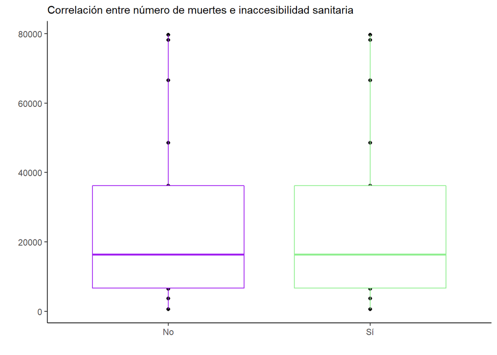

```r
Resultado_final %>%
  drop_na() %>%
  ggplot(data = ., mapping = aes(x = `Sí o no` , y = Total_muertes)) +
  geom_point(na.rm = TRUE) +
  geom_boxplot(na.rm = TRUE, col= c("purple", "lightgreen"))+
  labs(x = " ", y = " ",
       subtitle = "Correlación entre número de muertes e inaccesibilidad sanitaria") +
  theme_classic()
```

### Conclusiones

En el gráfico anterior se muestra la relación entre la inaccesibilidad a la asistencia sanitaria y el total de defunciones por comunidad autónoma. En un principio creíamos que en aquellas comunidades en las que hay una mayor inaccesibilidad sanitaria, la tasa de mortalidad también sería mayor. Sin embargo, tal como muestra el box-plot, la inaccesibilidad parece no ser un determinante, o al menos no en gran medida, sobre el total de muertes que se producen a nivel nacional.

### **Inaccesibilidad y dificultades de transporte (por comunidad autónoma)**:

- Importamos el set de datos del INE de Inaccesibilidad y dificultades de transporte agrupados por comunidad autónoma):

```r
library(readr)
Inaccesibilidad_y_dificultades_de_transporte <- read_csv2("DATOS/Inaccesibilidad y dificultades de transporte.csv")
```

```
## i Using "','" as decimal and "'.'" as grouping mark. Use `read_delim()` for more control.
```

### Análisis de datos:

- Obtenemos el número de columnas que tiene:

```r
str(Inaccesibilidad_y_dificultades_de_transporte)
```

```
## spec_tbl_df [300 x 4] (S3: spec_tbl_df/tbl_df/tbl/data.frame)
##  $ Sexo              : chr [1:300] "Ambos sexos" "Ambos sexos" "Ambos sexos" "Ambos sexos" ...
##  $ Comunidad autónoma: chr [1:300] "Total Nacional" "Total Nacional" "Total Nacional" "Total Nacional" ...
##  $ Sí o no           : chr [1:300] "TOTAL" "Sí" "No" "No necesitó asistencia" ...
##  $ Total             : num [1:300] 39974.1 409.5 35220.4 4330.9 13.4 ...
##  - attr(*, "spec")=
##   .. cols(
##   ..   Sexo = col_character(),
##   ..   `Comunidad autónoma` = col_character(),
##   ..   `Sí o no` = col_character(),
##   ..   Total = col_number()
##   .. )
##  - attr(*, "problems")=<externalptr>
```

- Especificamos de que tipo son:

```r
spec(Inaccesibilidad_y_dificultades_de_transporte)
```

- Obtenemos resumen de los resultados:

```r
summary(Inaccesibilidad_y_dificultades_de_transporte)
```

```
##      Sexo           Comunidad autónoma   Sí o no              Total
##  Length:300         Length:300         Length:300         Min.   :    0.00
##  Class :character   Class :character   Class :character   1st Qu.:    2.78
##  Mode  :character   Mode  :character   Mode  :character   Median :   66.65
##                                                           Mean   : 1065.98
##                                                           3rd Qu.:  619.35
##                                                           Max.   :39974.10
```

-**Nuestro set de datos esta compuesto por 4 columnas**:

- **Sexo**: compuesto por 300 elementos, clase caracter. Pueden ser hombres, mujeres o ambos sexos.
- **Comunidad autonónoma**: compuesto por 300 elementos, clase caracter. Dividido por el total nacional y las diferentes comunidades autonomas (Andalucia, Aragón, Asturias, Islas Baleares, Canarias, Cantabria, Castilla y León, Castilla la Mancha, Cataluña,Comunitat Valenciana, Extremadura, Galicia, Madrid, Región de Murcia, Comunidad Foral de Navarra, País Vasco, La Rioja, Cueuta, Melilla).
- **Si o No**: compuesto por 300 elementos, clase caracter. Muestra cuantas personas participaron en la encuesta, el total esta divididos en las personas que SI sufrieron inaccsesibilidad, quienes NO, las personas que no necesitaron asistencia y por último las que no constan.
- **Total**: compuesto por 300 elementos clase numerica. Es el recuento total de cada variable distinta.

```r
library(tidyverse)
```

- Seleccionamos sólo aquellas variables que nos interesan: Sí o no / Total/ Comunidad autónoma/Sexo

```r
Inaccesibilidad_transporte <-
  Inaccesibilidad_y_dificultades_de_transporte %>%
  select(`Comunidad autónoma`, `Sí o no`, Total, `Sexo`)

Inaccesibilidad_transporte
```

```
## # A tibble: 300 x 4
##    `Comunidad autónoma` `Sí o no`                Total Sexo
##    <chr>                <chr>                    <dbl> <chr>
##  1 Total Nacional       TOTAL                  39974.  Ambos sexos
##  2 Total Nacional       Sí                       410.  Ambos sexos
##  3 Total Nacional       No                     35220.  Ambos sexos
##  4 Total Nacional       No necesitó asistencia  4331.  Ambos sexos
##  5 Total Nacional       No consta                 13.4 Ambos sexos
##  6 Andalucía            TOTAL                   7096.  Ambos sexos
##  7 Andalucía            Sí                        88.9 Ambos sexos
##  8 Andalucía            No                      6453.  Ambos sexos
##  9 Andalucía            No necesitó asistencia   554.  Ambos sexos
## 10 Andalucía            No consta                  0   Ambos sexos
## # ... with 290 more rows
```

### Gráficos:

**1) Queremos ver en las diferentes comunidades autónomas de España el rango de inaccesibilidad que se ha producido.**

- Filtramos los datos que queremos (si han sufrido inaccesibilidad) y agrupamos las Comunidades autónomas

```r
Datos_filtrados<-
Inaccesibilidad_transporte %>%
  filter(`Comunidad autónoma`!="Total Nacional" & `Sí o no` != "TOTAL" & `Sí o no` != "No" & `Sí o no` != "No necesitó asistencia" & `Sí o no` != "No consta",`Sexo` != "Hombres"&`Sexo` !="Mujeres")%>%
group_by(`Comunidad autónoma`,`Sexo`)

str(Datos_filtrados)
```

```
## grouped_df [19 x 4] (S3: grouped_df/tbl_df/tbl/data.frame)
##  $ Comunidad autónoma: chr [1:19] "Andalucía" "Aragón" "Asturias, Principado de" "Balears, Illes" ...
##  $ Sí o no           : chr [1:19] "Sí" "Sí" "Sí" "Sí" ...
##  $ Total             : num [1:19] 88.9 16.2 3.7 12.1 47.6 0.6 23 5.3 51 55.1 ...
##  $ Sexo              : chr [1:19] "Ambos sexos" "Ambos sexos" "Ambos sexos" "Ambos sexos" ...
##  - attr(*, "groups")= tibble [19 x 3] (S3: tbl_df/tbl/data.frame)
##   ..$ Comunidad autónoma: chr [1:19] "Andalucía" "Aragón" "Asturias, Principado de" "Balears, Illes" ...
##   ..$ Sexo              : chr [1:19] "Ambos sexos" "Ambos sexos" "Ambos sexos" "Ambos sexos" ...
##   ..$ .rows             : list<int> [1:19]
##   .. ..$ : int 1
##   .. ..$ : int 2
##   .. ..$ : int 3
##   .. ..$ : int 4
##   .. ..$ : int 5
##   .. ..$ : int 6
##   .. ..$ : int 8
##   .. ..$ : int 7
##   .. ..$ : int 9
##   .. ..$ : int 18
##   .. ..$ : int 10
##   .. ..$ : int 11
##   .. ..$ : int 12
##   .. ..$ : int 13
##   .. ..$ : int 19
##   .. ..$ : int 14
##   .. ..$ : int 15
##   .. ..$ : int 16
##   .. ..$ : int 17
##   .. ..@ ptype: int(0)
##   ..- attr(*, ".drop")= logi TRUE
```

```r
Datos_filtrados
```

```
## # A tibble: 19 x 4
## # Groups:   Comunidad autónoma, Sexo [19]
##    `Comunidad autónoma`        `Sí o no` Total Sexo
##    <chr>                       <chr>     <dbl> <chr>
##  1 Andalucía                   Sí         88.9 Ambos sexos
##  2 Aragón                      Sí         16.2 Ambos sexos
##  3 Asturias, Principado de     Sí          3.7 Ambos sexos
##  4 Balears, Illes              Sí         12.1 Ambos sexos
##  5 Canarias                    Sí         47.6 Ambos sexos
##  6 Cantabria                   Sí          0.6 Ambos sexos
##  7 Castilla y León             Sí         23   Ambos sexos
##  8 Castilla - La Mancha        Sí          5.3 Ambos sexos
##  9 Cataluña                    Sí         51   Ambos sexos
## 10 Comunitat Valenciana        Sí         55.1 Ambos sexos
## 11 Extremadura                 Sí         12.2 Ambos sexos
## 12 Galicia                     Sí         30.5 Ambos sexos
## 13 Madrid, Comunidad de        Sí         22.5 Ambos sexos
## 14 Murcia, Región de           Sí          3.6 Ambos sexos
## 15 Navarra, Comunidad Foral de Sí          6.9 Ambos sexos
## 16 País Vasco                  Sí         24.4 Ambos sexos
## 17 Rioja, La                   Sí          5.2 Ambos sexos
## 18 Ceuta                       Sí          0   Ambos sexos
## 19 Melilla                     Sí          0.9 Ambos sexos
```

- Hacemos el gráfico de barras:

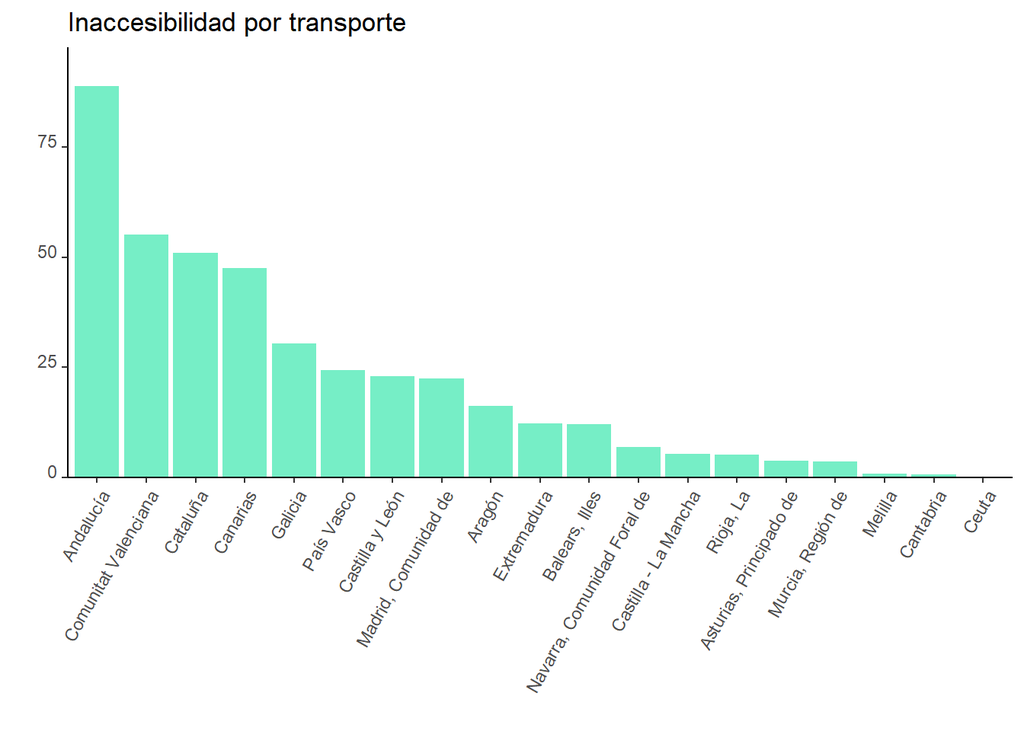

```r
Resultado3 <-
Datos_filtrados %>%
  drop_na() %>%
  ggplot(data = .,
       mapping = aes(x=reorder(`Comunidad autónoma`,-Total), y= Total)) +
  geom_bar(stat='identity',fill = "aquamarine2")+
  theme_classic()+
  theme(axis.text.x = element_text(angle = 60, vjust = 1, hjust=1))+
  theme(axis.text.y = element_text(angle = 0, vjust = 0, hjust=1))+
  labs(title= "Inaccesibilidad por transporte", x= " ", y= " ")+
  scale_y_continuous(expand = expansion(mult = c(0, .1)))

Resultado3
```

### Conclusiones:

En el gráfico anterior se muestran las personas que han sufrido inaccesibilidad o demora excesiva a la asistencia sanitaria debido al transporte o la distancia. La comparación que hemos realizado es por comunidades autónomas y hemos ordenado en el eje X, teniendo en cuenta los valores de mayor a menor del eje Y. Las conclusiones que podemos sacar son las siguientes: la comunidad que más ha sufrido es Andalucía, seguida de la Comunidad Valenciana. En cambio, las que menos Cantabria y las ciudades de Ceuta y Melilla.Además les siguen de cerca Murcia, Asturias y la Rioja. En el medio con valores medios nos encontramos por ejemplo a País Vasco, Castilla Y León y Madrid.

**2) Queremos comparar la inaccesibilidad causada por transporte entre hombres y mujeres en el total nacional**

- Seleccionamos sólo aquellas variables que nos interesan: Sí o no / Total/ Comunidad autónoma/Sexo

```r
Inaccesibilidad_sexos <-
  Inaccesibilidad_y_dificultades_de_transporte %>%
  select(`Sí o no`, Total, `Sexo`, `Comunidad autónoma`)

Inaccesibilidad_sexos
```

```
## # A tibble: 300 x 4
##    `Sí o no`                Total Sexo        `Comunidad autónoma`
##    <chr>                    <dbl> <chr>       <chr>
##  1 TOTAL                  39974.  Ambos sexos Total Nacional
##  2 Sí                       410.  Ambos sexos Total Nacional
##  3 No                     35220.  Ambos sexos Total Nacional
##  4 No necesitó asistencia  4331.  Ambos sexos Total Nacional
##  5 No consta                 13.4 Ambos sexos Total Nacional
##  6 TOTAL                   7096.  Ambos sexos Andalucía
##  7 Sí                        88.9 Ambos sexos Andalucía
##  8 No                      6453.  Ambos sexos Andalucía
##  9 No necesitó asistencia   554.  Ambos sexos Andalucía
## 10 No consta                  0   Ambos sexos Andalucía
## # ... with 290 more rows
```

- Filtramos los datos que queremos (si han sufrido inaccesibilidad) y agrupamos por sexo

```r
Datos_filtrados2<-
Inaccesibilidad_sexos %>%
  filter(`Comunidad autónoma`=="Total Nacional" & `Sí o no` != "TOTAL" & `Sí o no` != "No" & `Sí o no` != "No necesitó asistencia" & `Sí o no` != "No consta",`Sexo` != "Ambos sexos")%>%
group_by(`Comunidad autónoma`, `Sexo`)

str(Datos_filtrados2)
```

```
## grouped_df [2 x 4] (S3: grouped_df/tbl_df/tbl/data.frame)
##  $ Sí o no           : chr [1:2] "Sí" "Sí"
##  $ Total             : num [1:2] 162 247
##  $ Sexo              : chr [1:2] "Hombres" "Mujeres"
##  $ Comunidad autónoma: chr [1:2] "Total Nacional" "Total Nacional"
##  - attr(*, "groups")= tibble [2 x 3] (S3: tbl_df/tbl/data.frame)
##   ..$ Comunidad autónoma: chr [1:2] "Total Nacional" "Total Nacional"
##   ..$ Sexo              : chr [1:2] "Hombres" "Mujeres"
##   ..$ .rows             : list<int> [1:2]
##   .. ..$ : int 1
##   .. ..$ : int 2
##   .. ..@ ptype: int(0)
##   ..- attr(*, ".drop")= logi TRUE
```

```r
Datos_filtrados2
```

```
## # A tibble: 2 x 4
## # Groups:   Comunidad autónoma, Sexo [2]
##   `Sí o no` Total Sexo    `Comunidad autónoma`
##   <chr>     <dbl> <chr>   <chr>
## 1 Sí         162. Hombres Total Nacional
## 2 Sí         247. Mujeres Total Nacional
```

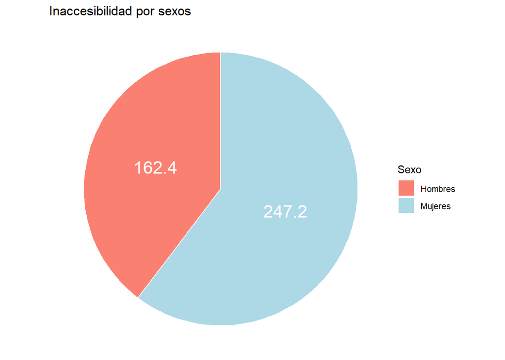

```r
Resultado4 <-
Datos_filtrados2 %>%
drop_na() %>%
ggplot(data=.,aes(x='Sexo',y=Total, fill =Sexo))+
  geom_bar(stat = "identity",
           color="white")+
    geom_text(aes(label=Total),
              position=position_stack(vjust=0.5),color="white",size=6)+
  coord_polar(theta = "y")+
  scale_fill_manual(values=c("salmon", "lightblue"))+
    theme_void()+
    labs(title="Inaccesibilidad por sexos")

Resultado4
```

### Conclusiones:

En el gráfico anterior se muestran las personas que han sufrido inaccesibilidad o demora excesiva a la asistencia sanitaria debido al transporte o la distancia.  
La comparación que hemos realizado es por sexos, es decir, entre hombres y mujeres. Podemos observar que hay una diferencia entre sexos notable, las mujeres han sufrido mayor inaccesibilidad que los hombres, un un total de 247.2 frente al de los hombres de 162,4. Nos imaginabamos que saldria una diferencia, pero no nos esperabamos que fuera tan grande.  
En conclusión, este podría ser un ejemplo de nuestra sociedad donde una vez más los datos muestran como las mujeres sufren un grado de exclusión mayor. Tal vez, los resultados de este estudio pueden ser un punto de partida para el desarrollo de políticas sanitarias y de protocolos institucionales más igualitarios para todo el mundo.